# MKT 500T

Spring 2018 HW1

Sami Cheong

Jan 28 2018

# Projecting customer retention rates

## Data

We are given the following customer retention data,starting with 1000 customers, but gradually decreasing over 12 years. For this assignment, we will use data from years 1-4:

| Year | Regular | High_End |
| --- | --- | --- |
| 0 | 1000 | 1000 |
| 1 | 631 | 869 |
| 2 | 468 | 743 |
| 3 | 382 | 653 |
| 4 | 326 | 593 |

to predict the following retention rates in the following periods:

| Year | Regular | High_End |
| --- | --- | --- |
| 5 | 289 | 551 |
| 6 | 262 | 517 |
| 7 | 241 | 491 |
| 8 | 223 | 468 |
| 9 | 207 | 445 |
| 10 | 194 | 427 |
| 11 | 183 | 409 |
| 12 | 173 | 394 |

Notice that the Regular segment has a significantly lower % of ‘Alive’ customers than the High End semengt:

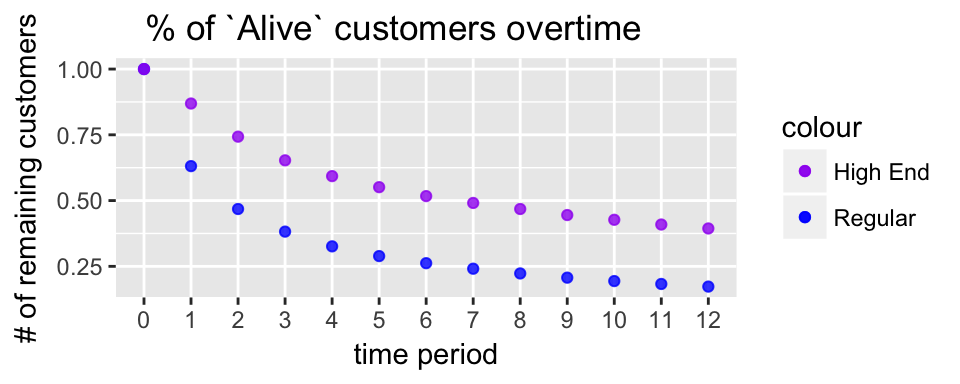

## Basic statistics First, let’s take a look at the churn rates and retention rates of each customer segment:

| Year | Regular | High_End | Churn_R | Churn_H | Ret_R | Ret_H |
| --- | --- | --- | --- | --- | --- | --- |
| 0 | 1000 | 1000 | 0 | 0 | 1.000 | 1.000 |
| 1 | 631 | 869 | 369 | 131 | 0.631 | 0.869 |
| 2 | 468 | 743 | 163 | 126 | 0.468 | 0.743 |
| 3 | 382 | 653 | 86 | 90 | 0.382 | 0.653 |
| 4 | 326 | 593 | 56 | 60 | 0.326 | 0.593 |

## Model

Since $P(T=t) = \int_{0}^{1} f(t|\theta) p(\theta) d\theta$, after some algebra we can deduce that $P(T=t)$ follows the shifted Beta Geometric Distribution, which is defined by the following:
$$P(T=t) = \begin{cases}\frac{\alpha}{\alpha+\beta} & \text{ for } t= 1, \\
\frac{\beta + t -1}{\alpha + \beta + t -1}P(T=t-1) & \text{ for } t = 2, 3, 4,...\end{cases}.$$

In here, $\alpha$ and $\beta$ are obtained by maximizing the log-likelihood function defined by
$$l(\alpha,\beta) = \sum_{t=1}^{4} c_t \ln(P(T=t|\theta)) + n_4 ln(P > 4|\theta),$$
where $c_i$ is the number of customers who churns at time $t$ and $n_4$ is the number of ‘survivors’ at the end of the $4^{th}$ season.

This parameter estimation procedure is implemented in R using the code provided in [`sBG.r`](https://github.com/samimath/Customer_Analytics/blob/master/code/sBG.R), presented as follows:

```r
# define 'survivors' for each segment
surv.R<-insamp.data$Regular[nrow(insamp.data)]
surv.H<-insamp.data$High_End[nrow(insamp.data)]

par.init=c(0.6,0.6)
## regular segment:
result.reg = optim(par=par.init,fn=sBG.LL,
                    churn.data = insamp.data$Churn_R[2:nrow(insamp.data)],
                    survivors = surv.R,control=list(fnscale=-1,reltol=1e-18))
# result is in log-scale, so transforming it using exp()
par.final.reg = exp(result.reg$par)
## high end segment:
result.high = optim(par=par.init,fn=sBG.LL,
                    churn.data = insamp.data$Churn_H[2:nrow(insamp.data)],
                    survivors = surv.H,control=list(fnscale=-1,reltol=1e-18))
par.final.high = exp(result.high$par)

pmf.reg<-sBG.pmf(par.final.reg[1],par.final.reg[2],12)


pmf.high<-sBG.pmf(par.final.high[1],par.final.high[2],12)

LL.reg<-sBG.LL(par.final.reg,insamp.data$Churn_R[2:nrow(insamp.data)],surv.R,debug.flag=F)

LL.high<-sBG.LL(par.final.high,insamp.data$Churn_H[2:nrow(insamp.data)],surv.H,debug.flag=F)

LL<-c(LL.reg,LL.high)
```

## Result

Using 4 years of training data, we obtained the following best estimates for $\alpha$ and $\beta.$ Notice that estimates for the High End segment has a worse likelihood value than the Regular segment, this suggests that the High End model may have a lower goodness-of-fit compared to the Regular one.

|  | alpha | beta | log-likelihood |
| --- | --- | --- | --- |
| Regular | 0.763665 | 1.295830 | -1427.933 |
| High End | 1.280976 | 7.790384 | -2654.386 |

Putting it all together:

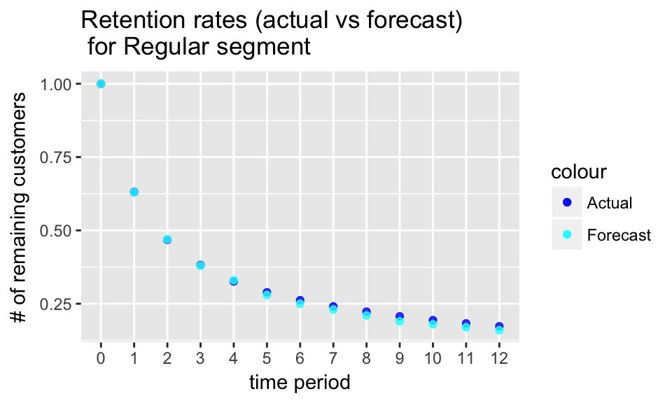

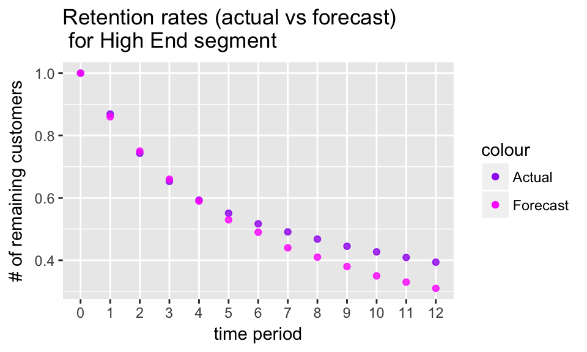

| Year | Ret_R | Forecast_R | APE_R | Ret_H | Forecast_H | APE_H |
| --- | --- | --- | --- | --- | --- | --- |
| 1 | 0.631 | 0.63 | 0.00 | 0.869 | 0.86 | 0.01 |
| 2 | 0.468 | 0.47 | 0.00 | 0.743 | 0.75 | 0.01 |
| 3 | 0.382 | 0.38 | 0.01 | 0.653 | 0.66 | 0.01 |
| 4 | 0.326 | 0.33 | 0.01 | 0.593 | 0.59 | 0.01 |
| 5 | 0.289 | 0.28 | 0.03 | 0.551 | 0.53 | 0.04 |
| 6 | 0.262 | 0.25 | 0.05 | 0.517 | 0.49 | 0.05 |
| 7 | 0.241 | 0.23 | 0.05 | 0.491 | 0.44 | 0.10 |
| 8 | 0.223 | 0.21 | 0.06 | 0.468 | 0.41 | 0.12 |
| 9 | 0.207 | 0.19 | 0.08 | 0.445 | 0.38 | 0.15 |
| 10 | 0.194 | 0.18 | 0.07 | 0.427 | 0.35 | 0.18 |
| 11 | 0.183 | 0.17 | 0.07 | 0.409 | 0.33 | 0.19 |
| 12 | 0.173 | 0.16 | 0.08 | 0.394 | 0.31 | 0.21 |

## Conclusion

In here, we calculate the in and out-of-sample average percent error. While both in-sample MAPE is relatively small (0.5 % and 1% respecitvely), the out-of-sample MAPE’s are much higher (6% and 13% respecitvely). Interestingly, when we compare the MAPE using 4 years of data vs that trained from 7 years of data, we see a better in-sample MAPE. This suggests that 4 years of data provide a better fit, but it is not as predictive compared to the model that uses 7 years of data.

|  | Regular | High End | High End (7 years data) |
| --- | --- | --- | --- |
| insample.MAPE | 0.00500 | 0.01 | 0.017 |
| outsample.MAPE | 0.06125 | 0.13 | 0.028 |

Another interesting observation is that, comparing to the example (where $\alpha = 0.668$ and $\beta = 3.806$) done in class, both $\alpha$ and $\beta$ here are estimated to be higher, which changes the density quite a bit as it moves the curve for $g(\theta)$ to an entirely different quadrant.

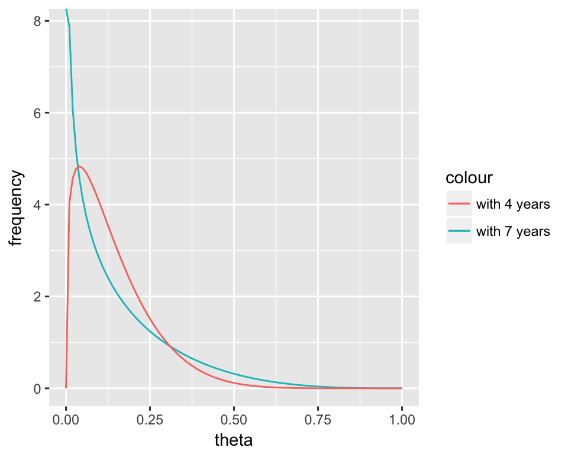